# Table of Contents

*New LaTeX commands declared in this cell. Expand to view.* $$ \newcommand\abs[1]{\left|#1\right|} \newcommand\dx[2]{\frac{\partial#1}{\partial#2}} \newcommand\ddx[2]{\frac{\partial^2#1}{\partial#2^2}} \newcommand\divv[1]{\nabla\cdot\vect{#1}} \newcommand\curl[1]{\nabla\times\vect{#1}} \newcommand\grad[1]{\nabla\vect{#1}} \newcommand{\ket}[1]{\left|#1\right\rangle} \newcommand{\bra}[1]{\left\langle#1\right|} \newcommand{\braket}[1]{\langle#1\rangle} \newcommand{\aint}[0]{\int_{-\infty}^{\infty}} \newcommand{\vect}[1]{\mathbf{#1}} \newcommand{\order}[1]{\mathcal{O}{#1}} $$

# Fourier Series

See discussions in:

- [Feynman I.50](https://www.feynmanlectures.caltech.edu/I_50.html)
- [MIT Lectures](https://ocw.mit.edu/courses/mechanical-engineering/2-161-signal-processing-continuous-and-discrete-fall-2008/lecture-notes/lecture_11.pdf)

# Fourier Transform

## Basics

The following discussion assumes evenly spaced steps in time $\Delta t$. The Fourier series of a function is its decomposition into individual sines and cosines:

$$ y(t) = \sum_{j=1}^n y_j \sin(2 \pi f_j t + \phi_j) \\ \text{With } _j = \frac{\omega_j}{2\pi} $$

.

If we take this to the continuum limit, summing over all frequencies,

$$ y(t) = \int_\infty^\infty Y(f) e^{-2\pi ift} df = \frac{1}{2\pi} \int_\infty^\infty Y(\frac{\omega}{2\pi}) ^{-i\omega t} d\omega \\ Y(f) = \int_\infty^\infty e^{2\pi i f t} dt$$

The two expressions are equivalent, though the $\omega$ version is more commonly seen in the context of quantum mechanics. The forms above are commonly called the forward Fourier transforms, though this has no deep meaning. The idea of going 'forward' likely results from our far more pedestrian experience of time as a dimension than frequency; we transform 'forward' to a new domain, and then inverse transform to return to 'normal'. This reasoning holds for the other common Fourier transforms as well; consider that position space is far more familiar to us than momentum space!

Another tool that will be useful is the Dirac delta function, the result of transforming forward, then back, and expecting your original function to return (a reasonable hope):

$$ \int_\infty^\infty e^{i\omega(t - t')} d\omega = 2\pi \delta(t-t')\\ $$

This function has the property of being zero everywhere except where t=t'. It has the following property when integrated with a function:

$$ \int y(t') \delta(t-t') dt' = y(t) $$

It thus has the inverse units of your integration variable.

## Discrete FT

Consider discretizing the above definition of the Fourier transform:

$$ \text{For }t = m \Delta t \text{, and} f_n = n/(N\Delta t): \\ y_m = \sum_{n=0}^{N-1} Y_n e^{-2\pi imn/N} \qquad Y_n =\frac{1}{N} \sum_{m=0} y_m e^{2 \pi i m n / N} $$

We can recreate the discrete version of a Dirac delta function with these definitions; the Kronecker delta function:

$$ \sum_{n=0}^{N-1}e^{2 \pi i n(m - m')/N} = N \delta_{m,m'} $$

Note that $\Delta t$ has disappeared from our discrete FT. There are subtleties involving the amount of information contained in the DFT between real and complex cases.

The DFT as implented below loops through the time and frequency indices, m and n, to compute matrix elements $$\bra{n} M \ket{m}$$, where $M$ is the [DFT Matrix](https://en.wikipedia.org/wiki/DFT_matrix). Since this matrix has $N\times N$ elements, the computation is of $\mathcal{O}(N^2)$, which will quickly become cumbersome. The [Fast Fourier Transform](https://en.wikipedia.org/wiki/Fast_Fourier_transform) is an algorithm much more efficient at computing the FT, which will be discussed in the next section.

### Nyquist Frequency

The Nyquist critical frequency is defined as $$ f_c = \frac{1}{2\Delta t} $$ The simplest case to consider is a sine wave: to properly sample a sine wave, you must take at least 2 points per cycle. This means that you need to sample at a minimum of twice the maximum frequency of your data to preserve information below that frequency. In a real device, such as an experimental setup limited by the response of particular electrical cables, there will probably be natural frequency cutoffs. You need to sample at twice the max frequency you want. For example, human hearing cuts off at around 20kHz. To be able to properly sample audio recordings for future listening (on headphones, for instance), you need to sample at twice this frequency. It's no accident that audio CDs sample at 44.1kHz!

```python
import numpy as np
import timeit
from matplotlib import pyplot as plt

from pfft import *
```

```python
np.random.seed(2)
func = np.random.random(1000)
a = pdft.dft(func, vectorize=False)
b = pdft.dft(func, vectorize=True)
c = pdft.dft_no_matrix(func)
```

```python
# Compare runtimes for these dfts to the fft

%timeit pdft.dft_no_matrix(func)
%timeit pdft.dft(func, vectorize=False)
%timeit pdft.dft(func, vectorize=True)
%timeit np.fft.fft(func)
```

```
1.1 s ± 14.5 ms per loop (mean ± std. dev. of 7 runs, 1 loop each)
3.9 s ± 36.6 ms per loop (mean ± std. dev. of 7 runs, 1 loop each)
43.4 ms ± 284 µs per loop (mean ± std. dev. of 7 runs, 10 loops each)
14.7 µs ± 112 ns per loop (mean ± std. dev. of 7 runs, 100000 loops each)
```

```python
"""To properly fit in the box with periodic boundary conditions,
we need the sine function to end at point N+1, not point N. Otherwise
we have two zeros next to each other, and there will be artefacts
present in the frequency spectrum. Specify your time step and choose
a compatible frequency. """

N = 2**10 # number of sample points
Tmax = 2 # s
#ts = np.linspace(0, 200/f, N)
#dt = np.diff(ts)[-1]
dt = Tmax/N
ts = np.arange(N) * dt
f = (20)/(Tmax) # frequency Hz
omega = 2 * np.pi * f # angular frequency
fs = np.linspace(0, 1/dt, N)
y0 = np.sin(omega * ts)
f_nyquist = 1 / 2 / np.diff(ts)[-1]

fs2 = pdft.dft_no_matrix(y0)
fs1 = pdft.dft(y0)
ys1 = pdft.idft(fs1)

f_nyquist, 1 / dt, f
```

```
(256.0, 512.0, 10.0)
```

```
(0, 1.998046875)
```

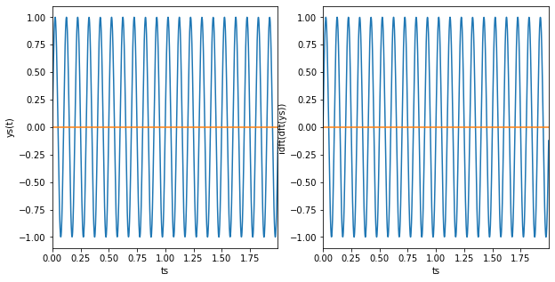

```python
plt.figure(figsize=(10,5))
plt.subplot(121)
plt.plot(ts, y0.real)
plt.plot(ts, y0.imag)
plt.xlabel('ts')
plt.ylabel('ys(t)')
plt.xlim(0, ts[-1])
plt.subplot(122)
plt.plot(ts, ys1.real)
plt.plot(ts, ys1.imag)
plt.xlabel('ts')
plt.ylabel('idft(dft(ys))')
plt.xlim(0, ts[-1])
```

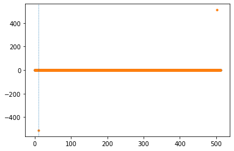

```python
plt.plot(fs, pdft.dft(y0).real,'.')
plt.plot(fs, pdft.dft(y0).imag,'.')
plt.axvline(f, linewidth=0.5, linestyle='--')
```

If the datatype is not set to complex, you will be discarding the phase of your DFT; $$ e^{i\theta} = \cos{\theta} + i \sin{\theta} $$ With only half of the information, you will introduce phase shifts into the Fourier transform. This can be easily tested by changing the functions above to read `dtype=float`.

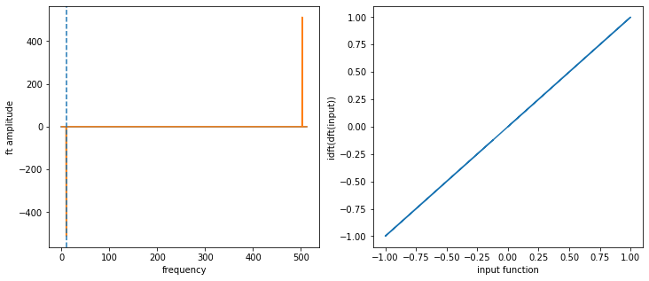

```python
plt.figure(figsize=(12,5))

plt.subplot(121)
plt.plot(fs,fs1.real)
plt.plot(fs,fs1.imag)
plt.axvline(f, linestyle='--')
plt.xlabel('frequency')
plt.ylabel('ft amplitude')

plt.subplot(122)
plt.plot(y0.real, ys1.real)
plt.xlabel('input function')
plt.ylabel('idft(dft(input))')
```

# FFT

The [Fast Fourier Transform (FFT)](https://en.wikipedia.org/wiki/Fast_Fourier_transform) is a ubiquitous algorithm for computing the Fourier transform of a dataset in $\mathcal{O}(N \log N) $ time. Compare the difference in the number of operations needed for the two cases.

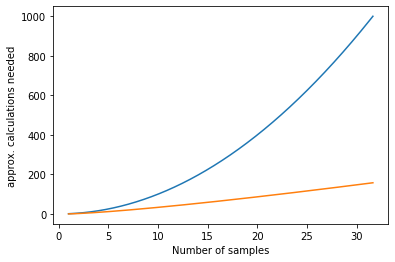

```python
Ns = np.logspace(0,1.5,1000)
plt.plot(Ns, Ns**2)
plt.plot(Ns, Ns * np.log2(Ns))
plt.xlabel('Number of samples')
plt.ylabel('approx. calculations needed')
```

$$ N = 8 = 2^3 \\ Y_n = \sum_{m=0}^{N-1} M_{n,m}Y_m \\ M_{nm} = e^{2 \pi i n m / N} \\ ex: Y_0 = \sum_{m=0}^{7} e^{2\pi i (0) m / N}y_m = y_0 + y_1 +...\\ \text{Split into even (e) & odd (o) m:} \\ Y_n = Y^e_n + w^n Y_n^o \qquad w = e^{2 \pi i / N} $$

$$ = \sum_{m'=0}^3 Y_{2m'} w^{2m'n} + w^n \sum_{m'=0}^3 Y_{2m'+1} w^{2m'n} \\ Y_n = Y^{e}_{n} + w^n y_n^o $$

For each level, we can recursively split the evens and odds again and get twice as many terms:

$$ Y^e_n = Y^{ee}_n + w^{2n} Y^{eo}_n \\ Y^o_n = Y^{oe}_n + w^{2n} Y^{oo}_n \\ $$

split until each $Y^{eoeoeoeoeoooeooeo...eoeooooeooooeeeeeoeoee}_n$, etc, term is a single element. For the n=8 example, this means three iterations of dividing the input array.

$$ Y^{ee}_n = Y^{eee}_{(0)} + w^{4n} Y^{eeo}_{(4)} \\ Y^{eo}_n = Y^{eoe}_{(2)} + w^{4n} Y^{eoo}_{(6)} \\ Y^{ee}_n = Y^{ooe}_{(3)} + w^{4n} Y^{ooo}_{(7)} \\ Y^{ee}_n = Y^{oee}_{(1)} + w^{4n} Y^{oeo}_{(5)} \\ $$

Recall what these Y terms are. Each is a broken down component of the initial array $Y_n$, $n \in [0,8).$ A string like eeo, eoe, etc, represents a reversed binary representation of the index to $Y_n$. $e\rightarrow 0, o \rightarrow 1$. If you flip the text string, you recover the binary representation of the index. An example is essential here.

$$ Y^{eoo}: eoo \rightarrow 011; \text{reversed, } 110 \rightarrow Y_6 \\ Y^{eoo} = Y_6 $$

So we can bit-reverse the index of the original array to find the new location of that element after the FFT algorithm begins working.

$$ Y_m = \sum_{n=0}^{N-1} y_n e^{-2\pi i m n / N} \\ $$

- To calculate $Y_m$, evaluate the four equations above for $n = 0, 1$\ $4 \times 2 = 8 $ calculations
- This gives you the next level to calculate, two equations for $n=0,1,2,3$\ $ 2 \times 2 \times 2 = 8$ calculations
- Return up once more; one equation for $n=0,1,2,3,4,5,6,7$\ $ 2 \times 2 \times 2 \times 1 = 8$ calculations
- $\rightarrow$ 8 + 8 + 8 calculations, or $3*8$, which happens to be

$$\order{N \log_2{N}}$$

#### Bit reversal

The point of bit reversing is a bookkeeping shortcut. Rather than splitting down the levels, sorting even/odd elements until they come out as a new array

$$[y_0, y_4, y_2, y_6, y_1, y_5, y_3, y_7]$$

There is a simple pattern here that is not obvious at first glance. We can recognize that, if we convert the indices to binary, *with the number of bits corresponding to $ln_2(len(y))$*, we get

$$[y_{000}, y_{100}, y_{010}, y_{110}, y_{001}, y_{101}, y_{011}, y_{111}]$$

And, if we reverse the order of each of these bits, the final result is

$$[y_{000}, y_{001}, y_{010}, y_{011}, y_{100}, y_{101}, y_{110}, y_{111}]$$

a slick trick that can save us time by instantly swapping our input array elements to the place that sorting would have put them already.

## Recursive FFT

Below is a sketch of the recursive fft algorithm. Note that this does not utilize the bit reversal technique; deriving this method led to the recognition of bit reversal as a bookkeeping trick, which is implemented in Iterative FFT below.

```
def _recursive_fft(data):
    """recursively compute the fft of the input data."""
    N = int(len(data))
    if N == 1:
        return data # The FT of a single element is itelf
    w_N = np.exp(-2j * np.pi / N)
    w = 1.0 + 0.0j

    data_even = data[0::2] # starts from 0 and moves two elements until N-2
    data_odd = data[1::2] # starts from 1 and moves two elements until N-1

    y_e = recursive_fft(data_even)
    y_o = recursive_fft(data_odd)

    y = np.zeros([N], dtype=complex)
    for k in range(0, N//2):
        t = w * y_o[k] # butterfly operation
        y[k] = y_e[k] + t
        y[k+N//2] = y_e[k] - t
        w = w * w_N
        del t
    return y
```

```python
# array slicing example
tes = np.linspace(0,31,32)
print(tes[:16][::2])
```

```
[ 0.  2.  4.  6.  8. 10. 12. 14.]
```

```python
pfft.recursive_fft(data=y0)
```

```
array([8.39470213e-16+0.00000000e+00j, 1.08946670e-14-4.21946824e-15j,
       2.04880249e-14+1.19737608e-14j, ...,
       1.36039644e-14-3.03724287e-15j, 2.04880249e-14-1.19737608e-14j,
       1.08946670e-14+4.21946824e-15j])
```

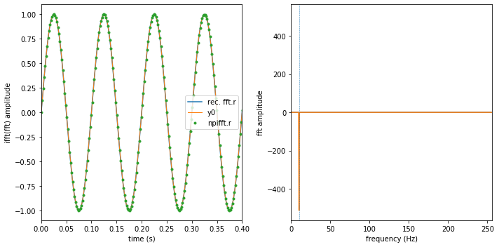

```python
fft_fs = pfft.recursive_fft(y0)
fft_y0 = pfft.recursive_ifft(fft_fs)

plt.figure(figsize=(10,5))
ax1 = plt.subplot(121)
ax1.plot(ts, fft_y0.real, '-', label='rec. fft.r')
#ax1.plot(ts, fft_y0.imag, '-', label='rec. fft.im')
ax1.plot(ts, y0, linewidth=1., label='y0')
#plt.xlim(0, 5/f)
ax1.set(xlim=(0,4/f))
ax1.set(xlabel='time (s)', ylabel='ifft(fft) amplitude')
ax1.plot(ts, np.fft.ifft(fft_fs).real, '.', linewidth=0.5, label='npifft.r')
#ax1.plot(ts, np.fft.ifft(fft_fs).imag, '--', linewidth=0.3, label='npifft.im')
plt.legend()

ax2 = plt.subplot(122)
ax2.plot(fs, fft_fs.real)
ax2.plot(fs, fft_fs.imag)
ax2.axvline(f, linestyle='--', linewidth=0.5)
#plt.plot(fs, np.fft.fft(y0).real, '--')
#plt.plot(fs, np.fft.fft(y0).imag, '--')
#ax2.set(xlim=(fs[0], 10*f))
ax2.set(xlabel='frequency (Hz)', ylabel='fft amplitude')
ax2.set(xlim=(0, f_nyquist))
#ax2.axvline(fs[-1]/2)

#ax2.axvline(f_nyquist - f, linewidth=0.7, linestyle='-')
plt.tight_layout()
```

```python
%timeit pfft.recursive_fft(y0)
%timeit np.fft.fft(y0)
```

```
8.09 ms ± 81.5 µs per loop (mean ± std. dev. of 7 runs, 100 loops each)
13.6 µs ± 117 ns per loop (mean ± std. dev. of 7 runs, 100000 loops each)
```

## Iterative FFT

The above recursive FFT is messy (I'm not sure where the extra frequency in the fft is coming from), and padding zeros is difficult without significantly more bookkeeping than I've done above. We will move from the bottom up in the tree describing the FFT, following the bit-reversal scheme.

```
def iterative_fft(cls, data):
    data = data.astype(complex)
    assert (np.log2(len(data)) % 1) == 0
    A = cls.reverse_array(data)
    N = int(len(A))
    S = int(np.log2(N))
    for s in range(1, S+1):
        m = int(2**s) # length of split array at each level
        w_m = np.exp(-2j * np.pi / m)
        for k in range(0, N, m): # by m
            w = 1.0 + 0.0j
            m_2 = (m // 2)
            for j in range(0, m_2):
                t = w * A[k + j + m_2]
                u = A[k + j]
                A[k + j] = u + t
                A[k + j + m_2] = u - t
                w = w * w_m
        return A
```

### Bit reversal

```
def bit_reverse(num, bits):
    num = int(num)
    return int('{:0{s}b}'.format(num, s=bits)[::-1], 2)
```

```python
import numpy as np
import timeit
from matplotlib import pyplot as plt

from pfft import *

# Let's use the data from above again.


N = 2**10 # number of sample points
Tmax = 2 # s
#ts = np.linspace(0, 200/f, N)
#dt = np.diff(ts)[-1]
dt = Tmax/N
ts = np.arange(N) * dt
f = (200)/(Tmax) # frequency Hz
omega = 2 * np.pi * f # angular frequency
fs = np.linspace(0, 1/dt, N)
y0 = np.sin(omega * ts)
f_nyquist = 1 / 2 / np.diff(ts)[-1]

f_nyquist, 1 / dt, f
```

```
(256.0, 512.0, 100.0)
```

```python
int('{:0{bits}b}'.format(12, bits=4)[::-1], 2) # base 2
```

```
3
```

```python
# test
a = np.linspace(0, 1023, 1024, dtype=complex)
assert(np.allclose(a, pfft.reverse_array(pfft.reverse_array(a))))
```

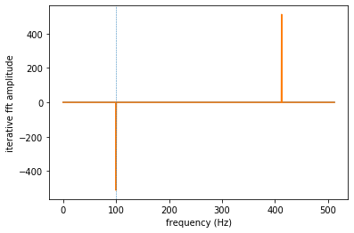

```python
freqs = pfft.iterative_fft(y0)
plt.plot(fs, freqs.real)
plt.plot(fs, freqs.imag)
#plt.xlim(0, f_nyquist)
plt.axvline(f, linewidth=0.5, linestyle='--')
#plt.axvline(f_nyquist-f, linewidth=0.5, linestyle='--')

plt.xlabel('frequency (Hz)')
plt.ylabel('iterative fft amplitude')
```

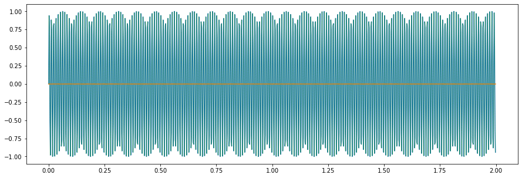

```python
plt.figure(figsize=(15,5))
plt.plot(ts, pfft.iterative_ifft(freqs).real)
plt.plot(ts, pfft.iterative_ifft(freqs).imag)
plt.plot(ts, y0, '--', linewidth=0.5)
```

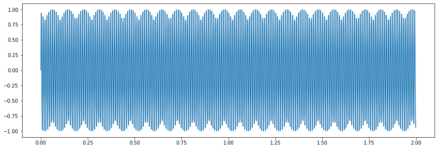

```python
plt.figure(figsize=(15,5))
plt.plot(ts, y0)
```

```python
assert(np.allclose(np.fft.fft(y0), pfft.iterative_fft(y0)))
assert(np.allclose(np.fft.ifft(y0), pfft.iterative_ifft(y0)))
```

## Comparative Efficiency

```python
%timeit pdft.dft_no_matrix(y0)
%timeit pdft.dft(y0, vectorize=False)
%timeit pdft.dft(y0)
%timeit pfft.recursive_fft(y0)
%timeit pfft.iterative_fft(y0)
%timeit np.fft.fft(y0)
```

```
1.29 s ± 77.9 ms per loop (mean ± std. dev. of 7 runs, 1 loop each)
4.41 s ± 168 ms per loop (mean ± std. dev. of 7 runs, 1 loop each)
57.7 ms ± 382 µs per loop (mean ± std. dev. of 7 runs, 10 loops each)
7.95 ms ± 66.2 µs per loop (mean ± std. dev. of 7 runs, 100 loops each)
6.34 ms ± 29.8 µs per loop (mean ± std. dev. of 7 runs, 100 loops each)
13.6 µs ± 41.5 ns per loop (mean ± std. dev. of 7 runs, 100000 loops each)
```

```python
1000**2 / (1000 * np.log2(1000))
```

```
100.34333188799373
```

## Sample interval and N

The interval over which to sample and the number of samples are the parameters most closely in our control. It was briefly mentioned above that discarding the imaginary part of the fft destroys the phase information, but this may have been obfuscated by the development of the crude fft. Let's see how a phase shift in a pure $\sin{\omega t}$ signal affects the fourier transform.

```python
1/np.diff(ts)[-1]
```

```
512.0
```

Good frequencies are $$ f = \frac{n}{T} \bigg \rvert_{-N/2}^{N/2 - 1} \\ \omega = \frac{2\pi n}{T} \bigg \rvert_{-N/2}^{N/2 - 1} \\ k = \frac{2\pi n}{L} \bigg \rvert_{-N/2}^{N/2 - 1} \\ $$

```
f_nyquist=51.15 Hz, f=15.9844 Hz
```

```
(0, 0.187683284457478)
```

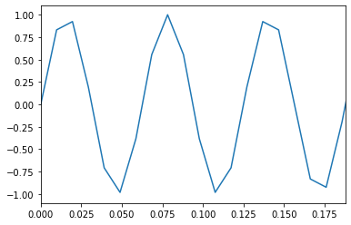

```python
N = 2**10
Tmax = 10
ts = np.linspace(0, 10, N)
dt = np.diff(ts)[-1]
f = (160)/(Tmax+dt) # Hz
f_nyquist = 1 / 2 / dt
assert(f <= f_nyquist)
fs = np.linspace(0, 1/np.diff(ts)[-1], N)
omega = 2 * np.pi * f # rad/s


# no phase shift series
y_t = np.sin(omega * ts)
Y_f = np.fft.fft(y_t)

# phase shift series
y_t1 = np.sin(omega * ts - np.pi/4)
Y_f1 = np.fft.fft(y_t1)

# the data below is deliberately not carefully chosen,
# so that its frequencies don't match up nicely with
# the sampling frequency above
y_t2 = (1 * np.sin(2 * np.pi * 2.5 * ts - np.pi/4) +
        1 * np.sin(2 * np.pi * 4.5 * ts + 0)) # superposition of two sines
Y_f2 = np.fft.fft(y_t2)
print('f_nyquist={:4g} Hz, f={:4g} Hz'.format(f_nyquist, f))

plt.plot(ts, y_t)
plt.xlim(0, 3/f)
```

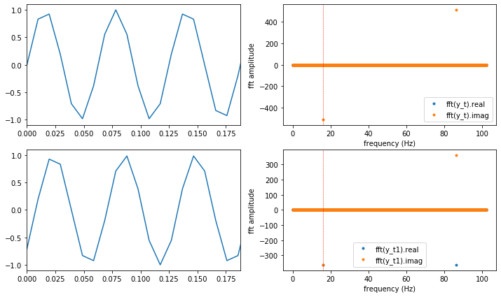

```python
plt.figure(figsize=(12,7))
plt.subplot(221)
plt.plot(ts, y_t)
plt.xlim(0, 3/f)

plt.subplot(222)
plt.plot(fs, Y_f.real, '.', label='fft(y_t).real')
plt.plot(fs, Y_f.imag, '.', label='fft(y_t).imag')
plt.legend()
plt.ylabel('fft amplitude')
plt.xlabel('frequency (Hz)')
plt.axvline(f, linestyle='--', linewidth=0.5, color='r')
#plt.xlim(0,fs[-1]/4)

plt.subplot(223)
plt.plot(ts, y_t1)
plt.xlim(0,3/f)
plt.subplot(224)
plt.plot(fs, Y_f1.real, '.', label='fft(y_t1).real')
plt.plot(fs, Y_f1.imag, '.', label='fft(y_t1).imag')
plt.legend()
plt.ylabel('fft amplitude')
plt.xlabel('frequency (Hz)')
plt.axvline(f, linestyle='--', linewidth=0.5, color='r')
#plt.xlim(0,fs[-1]/4)
```

From the first row of plots, you should be able to convince yourself that there should only be an imaginary piece to the frequency spectrum. From euler's equation, $$e^{i\omega t} = \cos{\omega t} + i \sin{\omega t},$$ the FT depends on a sine and a cosine contribution, but our initial signal was $\sin{\omega t}$. The cosine amplitude should then be zero.

The frequency spectrum has twice as many peaks as you'd expect; the components $Y_{N/2-n} = Y^*_{N/2+n}$. Since $ N/2 \rightarrow F_{\text{nyquist}} $, the duplicated frequencies will be rotated about the Nyquist frequency.

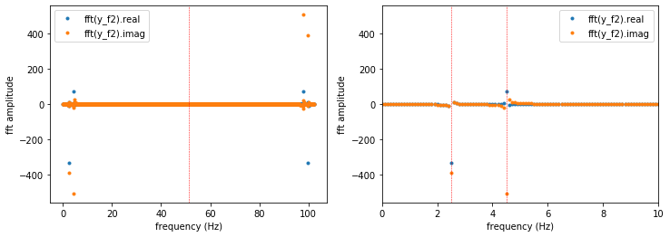

```python
plt.figure(figsize=(12,4))

plt.subplot(121)
plt.plot(fs, Y_f2.real, '.', label='fft(y_f2).real')
plt.plot(fs, Y_f2.imag, '.', label='fft(y_f2).imag')
plt.legend()
plt.ylabel('fft amplitude')
plt.xlabel('frequency (Hz)')
#plt.xlim(0,fs[-1]/2)
plt.axvline(f_nyquist, linestyle='--', color='r', linewidth=0.5)

plt.subplot(122)
plt.plot(fs, Y_f2.real, '.', label='fft(y_f2).real')
plt.plot(fs, Y_f2.imag, '.', label='fft(y_f2).imag')
plt.legend()
plt.ylabel('fft amplitude')
plt.xlabel('frequency (Hz)')
plt.xlim(0,10)
plt.axvline(2.5, linestyle='--', color='r',linewidth=0.5)
plt.axvline(4.5, linestyle='--', color='r', linewidth=0.5)
```

# Aliasing

The above discussion only used frequencies below the Nyquist frequency. If we sample above this, we run into problems.

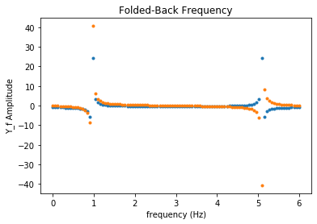

```python
f_nyquist = 3 #Hz
dt = 1 / f_nyquist / 2
N = 100
ts = np.linspace(0,N*dt,N)
y_t = np.sin(2*np.pi*5*ts)
fs = np.linspace(0,1/dt,N)
plt.plot(fs, np.fft.fft(y_t).real, '.')
plt.plot(fs, np.fft.fft(y_t).imag, '.')
#plt.xlim(0,f_nyquist)
plt.xlabel('frequency (Hz)')
plt.ylabel('Y_f Amplitude')
plt.title('Folded-Back Frequency')
```

If we move that distance from $f_{nq}$ again, we'll find our aliased frequency.

[Wagon Wheel effect on Wikipedia](https://en.wikipedia.org/wiki/Wagon-wheel_effect)

```
(0, 2.5)
```

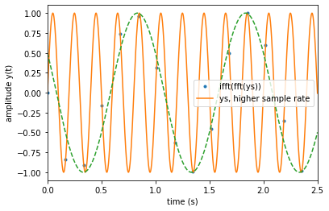

```python
plt.plot(ts, np.fft.ifft(np.fft.fft(y_t)).real, '.', label='ifft(fft(ys))')
ts1 = np.linspace(0, N*dt, 100*N)
plt.plot(ts1, np.sin(2*np.pi*5*ts1), label='ys, higher sample rate')
plt.plot(ts1, np.sin(2*np.pi*1*ts1-np.pi*7/6),'--')
plt.legend()
plt.xlabel('time (s)')
plt.ylabel('amplitude y(t)')
plt.xlim(0,2.5)
```

# Derivatives

We can use the Fourier transform to take derivatives of analytic, periodic functions.

$$ f(x) = e^{\cos{2\pi x/L}} \\ f'(x) = -\frac{2\pi}{L}f(x) \sin\frac{2\pi x}{L} \\ f''(x) = \frac{2\pi}{L}\bigg[- f'(x)\sin\frac{2\pi x}{L} - f(x)\frac{2\pi}{L}\cos{\frac{2\pi x}{L}} \bigg]\\ = \frac{4\pi^2}{L^2} f(x) \bigg[\sin^2{\frac{2\pi x}{L}} - \cos{\frac{2\pi x}{L}} \bigg] $$

```
_f_nyq =  1.6
sample rate = 0.628319
```

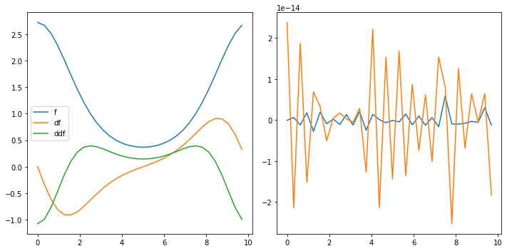

```python
def deriv(f, dx=1, d=1):
    """take the dth derivative of f,
    with windowing dx."""
    k = 2 * np.pi * np.fft.fftfreq(len(f), dx)
    return np.fft.ifft((1j*k)**d * np.fft.fft(f))

N = 2**5
L = 10
_dx = L/N
_xs = np.arange(N) * _dx
print('_f_nyq = {fnyq:4g}'.format(fnyq= 1 / 2 / _dx))
print('sample rate = {k:4g}'.format(k=2*np.pi/L))
__ks = 2 * np.pi * np.fft.fftfreq(N, _dx)
phi = 2 * np.pi * _xs / L

_ys = np.exp(np.cos(phi))
_dys = deriv(f=_ys, dx=_dx, d=1)
_ddys = deriv(f=_ys, dx=_dx, d=2)

a_dys = -2 * np.pi / L * _ys * np.sin(phi)
a_ddys = (2 * np.pi / L)**2 * _ys * (np.sin(phi)**2 - np.cos(phi))

plt.figure(figsize=(10,5))
dp1 = plt.subplot(121)
dp1.plot(_xs, _ys, label='f')
dp1.plot(_xs, _dys, label='df')
dp1.plot(_xs, _ddys, label='ddf')
dp1.legend()

dp2 = plt.subplot(122)
dp2.plot(_xs, a_dys - _dys)
dp2.plot(_xs, a_ddys - _ddys)

plt.tight_layout()
```

```
True
```

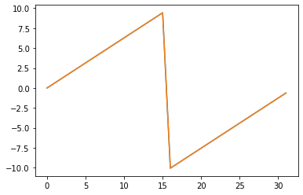

```python
#_ys2 = np.array(list(map(lambda x: np.exp(np.cos(2 * np.pi * x / L)), _xs)))
#assert(np.allclose(_ys, _ys2))


_k = 2 * np.pi / L
_ks = np.append(np.arange(0, N/2), np.arange(-N/2, 0)) * _k
plt.plot(_ks)
plt.plot(__ks)
np.allclose(_ks, __ks)
# This, just to make sure of what np.fft.fftfreqs does
```

# Errors

Errors come in two flavors from physics lingo - UV and IR.

## Ultraviolet (UV)

A wave cannot fit in a box with a frequency that will touch less than two points. I.E., the smallest wavelength that can fit in your box is 2*dx. Imagine an 8 point lattice with a standing wave of this wavelength:

$$ \text{(1) } \uparrow \downarrow \uparrow \downarrow \uparrow \downarrow \uparrow \downarrow \\ \text{(2) } \uparrow \uparrow \uparrow \uparrow \downarrow \downarrow \downarrow \downarrow $$

Case (1) has the smallest wavelength possible. Anything less than this and we can't represent it accurately; this will cause aliasing, and the resultant aliased wavelength will be larger than you want (lower energy). See *Numerical Recipes* for a discussion of aliasing as energy bleeding out of the edge of the PSD power spectrum.

These are called *ultraviolet* errors because the low wavelengths correspond to high energy waves (particles); thus the errors are in the ultraviolet regime on the electromagnetic scale.

## Infrared (IR)

Likewise, a wave with too large a wavelength will begin to lose features. If the wavelength is larger than case (2) above, you may end up with IR errors. We could fit a half wavelength into a box, but our periodic boundary conditions will make a discontinuity appear (consider what happened when there was just one extra zero in a Fourier transformed data set from improperly picking boundary conditions!)

## Gaussian Example

Consider a Gaussian in a centered box:

$$ f(x) = e^{-x^2 / 2 \sigma^2}, \qquad f'(x) = \frac{-x}{\sigma^2}f(x), \qquad f(k) = \sqrt{2\pi} \sigma e^{-k^2 \sigma^2/2} $$

We want the function to achieve [machine precision](https://en.wikipedia.org/wiki/Machine_epsilon). In this case, that means approaching $\epsilon = 2^{-52} \approx 2 \times 10^{-16}$.

- The full function must fit in the box (IR error).
- The frequency must not alias out (UV error).

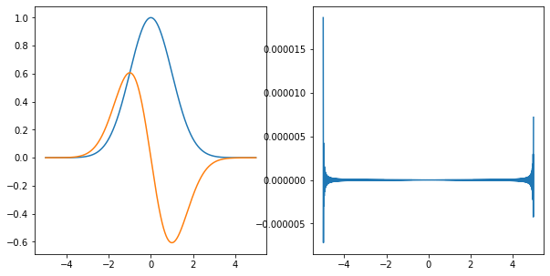

```python
# gaussian in a centered box
N = 2**10
L = 10
dx = L/N
xs = np.arange(N) * dx - L / 2
sigma = 1.0
k = 2 * np.pi * np.fft.fftfreq(N, dx)
f = np.exp(-xs**2 / 2 / sigma**2)
dfft = deriv(f=f, dx=dx, d=1)
df = - xs / sigma**2 * f
error = df - dfft

plt.figure(figsize=(10,5))
plt.subplot(121)
plt.plot(xs, f)
plt.plot(xs, df)
plt.subplot(122)
plt.plot(xs, error)
```

```
2.220446049250313e-16
 16.980848833699017 sigma
 47
```

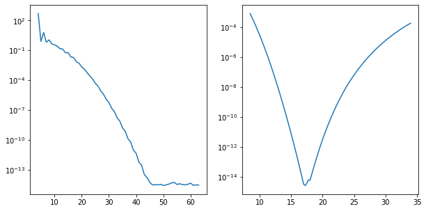

```python
# Let's look at the error over a range of values,
# and shoot for the values that get us close to machine precision.

# Use our rough estimate for L_opt
eps = np.finfo(float).eps
L = np.sqrt(-8 * np.log(eps)) * sigma
N_opt = int(np.ceil((L / np.pi / sigma) * np.sqrt(
        -2 * np.log(eps / np.sqrt(2 * np.pi * sigma**2)))))
print(eps, '\n', L,'sigma', '\n', N_opt)


Ns = np.arange(4,64)
Ls = np.linspace(L/2, 2*L, 100)

def get_error(N, L, sigma):
    """return the error for a periodic function,
    given its sampling and analytic derivative"""
    dx = L/N
    xs = np.arange(N) * dx - L / 2
    k = 2 * np.pi * np.fft.fftfreq(N, dx)
    f = np.array(list(map(lambda x: np.exp(-x**2 / 2 / sigma**2), xs)))
    df = np.array(list(map(lambda x: -x / sigma**2 * (
            np.exp(-x**2 / 2 / sigma**2)), xs)))
    dfft = deriv(f=f, dx=dx, d=1)
    error = df - dfft
    return abs(error/abs(df).max()).max()

errs_N = [get_error(N=_N, L=L, sigma=sigma) for _N in Ns]
errs_L = [get_error(N=N_opt, L=_L, sigma=sigma) for _L in Ls]

plt.figure(figsize=(10,5))
plt.subplot(121)
plt.semilogy(Ns, errs_N)
plt.subplot(122)
plt.semilogy(Ls, errs_L)
```

This estimation scheme for optimal values of N and L is great if we have an analytic form to play with, but what if the function is too complicated for this? We have a few options:

- Brute force. We could have done the above for a large value of N while sweeping with multiple values of L and checking properties of the function (such as the energy in a physical system). This is not reasonable if the simulation is computationally expensive.
- Asymptotics. If we have a differential equation, we could write it down and make estimates for large values of x, focusing on a simpler regime of the problem. This requires some more clever thinking.

# Power Spectrum (incomplete)

Obtaining the power spectrum via fft requires using the convolution of two functions.

## Convolution

```python
1.3/0.0667
```

```
19.49025487256372
```

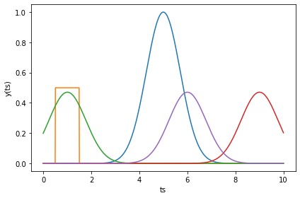

```python
ts = np.linspace(0,10, 2**10)
a = np.exp(-(ts-5)**2)
b = np.zeros(len(ts))
for i in range(len(ts)):
    if 0.5 < ts[i] < 1.5: b[i] = 0.5
    else: b[i] = 0

plt.plot(ts, a)
plt.plot(ts, b)
c = 0.01 * np.convolve(a, b, mode='same')
plt.plot(ts, c)
plt.xlabel('ts')
plt.ylabel('y(ts)')
plt.tight_layout()
# compare to manually fourier transforming, then transforming back
plt.plot(ts, 0.01 * np.correlate(a,b, mode='same'))
c2 = 0.01 * np.fft.ifft(np.fft.fft(a)*np.fft.fft(b))
plt.plot(ts, c2)
```

```
0.15915494309189526 1.0079813062486702
```

```
(0, 1.5119719593730054)
```

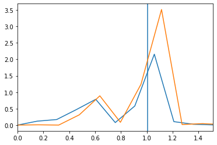

```python
from scipy.signal import periodogram
ts = np.linspace(0, 2*np.pi, 2*10)
dt = np.diff(ts)[-1]
fs = np.linspace(0, 1/dt, len(ts))
a = np.sin(2*np.pi*1/dt/3 * ts) + 0.7*np.sin(2*np.pi*1/dt/5.4 * ts + np.pi/9)

print(np.diff(fs)[-1], fs[-1]/3)
freqs, Pxx = periodogram(a, 1/dt)

plt.plot(freqs, Pxx)
plt.axvline(fs[-1]/3)

corr = np.correlate(a,a, mode='same')
power = 0.001*np.fft.fft(corr).real[:]**2 + np.fft.fft(corr).imag[:]**2
plt.plot(fs, power)
plt.xlim(0,fs[-1]/2)
```

## Correlation / Autocorrelation

We will need to integrate a function to obtain the correlation between it and itself, lagged. The correlation is defined as $$ Corr[y](\tau) = \int_{\infty}^{\infty} y(t)*y(t + \tau)d\tau $$

```python
def integrate(func, ts):
    """integrate an array using Newton-Cotes trapezoid method. """

    dt = (ts[-1] - ts[0]) / len(ts)
    if hasattr(func, '__len__') and (not isinstance(func, str)):
        data = func
    else:
        data = func(ts)
    return (sum(data[1:-1]) + (data[-1] + data[0])/2) * dt

ts = np.linspace(0,np.pi,10000)
dt = ((ts[-1]-ts[0])/len(ts))

def y_t(t):
    return np.sin(t)

I = integrate(y_t, ts)

error = (2 - I) / I
I, error, dt
```

```
(1.9997999835490183, 0.00010001822813634565, 0.0003141592653589793)
```

Correlation: $$ Corr[A, B][n] = \sum_{m = 0}^{m= N-1} A[m]B[n-m] $$

```python
np.correlate(a, b)
def correlation(a, b):
    """return the correlation of two arrays."""
    Cab = 0 * a
    N = len(a)
    for i in range(0,N):
        for j in range(0,N):
            Cab[i] += a[j].conj() * b[(i + j)%N]
    return Cab

correlation(a,b)

_ffta, _fftb = np.fft.fft(a), np.fft.fft(b)
_fftab = np.fft.fft(a.conj() * b)
```

[output not shown]

```python
from scipy.signal import fftconvolve

assert np.allclose(np.convolve(a, b), fftconvolve(a,b))
%timeit np.convolve(a,b)
%timeit fftconvolve(a,b)
```

```python
plt.plot(np.convolve(a,b))
#plt.plot(correlation(a,b))
#plt.plot(np.correlate(a,b,'same'))
```

# Parseval's Theorem

[Parseval's Theorem](https://en.wikipedia.org/wiki/Parseval%27s_theorem) relates the total energy in the time domain to the total energy in the frequency domain. The Fourier transform takes you from one basis to another, but the physical quantities associated with the system cannot change. Consider this in the continuous and discrete cases:

$$ \int dt e^{-i\omega t} y(t) = Y(\omega) \qquad \frac{1}{2\pi} \int d\omega e^{i \omega t} Y(\omega) = y(t) \\ \sum_{n=0}^{N-1} e^{-i \omega n / N} y_n = Y_m \qquad \frac{1}{N} \sum_{m=0}^{N-1} e^{i \omega m / N} Y_m = y_n \ $$

Parseval's Theorem states that:

$$ \boxed{ \int dt \abs{y(t)}^2 = \frac{1}{2\pi}\int d\omega \abs{Y({\omega})}^2 \\ \sum_{n=0}^{N-1} \abs{y_n}^2 = \frac{1}{N} \sum_{n=0}^{N-1} \abs{y_m}^2 } $$

```python
assert(np.allclose(sum(np.square(np.abs(y0))), sum(np.square(np.abs(np.fft.fft(y0))))/len(y0)))
```

# Numerical Issues

$$ \nabla^2(ab) = \nabla (b \nabla a + a \nabla b) \\ = \nabla b \cdot \nabla a + b \nabla ^2 a + \nabla a \cdot \nabla b + a \nabla ^2 b \\ \rightarrow \nabla a \cdot \nabla b = \frac{\nabla ^2 (ab) - a \nabla b - b \nabla a}{2} \\ $$

```python
N = 32
L = 10
dx = L/N
x = np.arange(N) * dx - L/2
ks = 2 * np.pi * np.fft.fftfreq(N, dx)

def grad(f):
    return np.fft.ifft((1j*k) * np.fft.fft(f))

def laplacian(f):
    return np.fft.ifft((1j*k)**2 * np.fft.fft(f))

def grad_dot_grad(a, b):
    return (laplacian(a*b) - a*laplacian(b) - b*laplacian(a))/2
```

```
False
```

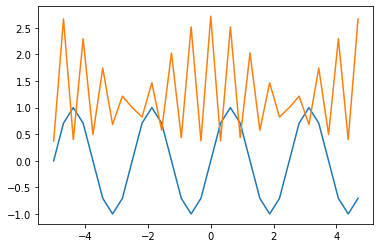

```python
# make two functions, a and b
a = np.sin(ks[4] * x)
b = np.exp(np.cos(ks[15] * x))
plt.plot(x, a)
plt.plot(x, b)
np.allclose(grad(a*b), a*grad(b) + b*grad(a))
```

Why does this fail? The set of frequencies accessible to a and b are obtained with `np.fftfreq()`, but a*b has a different set of frequencies. Borrowing from a discussion by MMF, the dft has frequencies

$$ a_k = \sum_k e^{-ikx}a_x, \qquad k_n = \frac{2\pi n}{L} \in \bigg [ \frac{-N}{2} \leq n \leq \frac{N}{2} \bigg ) $$

If we multiply our two functions $a_x$ and $b_x$, the spectrum now looks like

$$ a_x b_x = \frac{1}{N^2} \sum_{k_a, k_b} e^{i(k_a+k_b)x}A_{k_1}B_{k_2} = \frac{1}{N}\sum_p e^{ipx}C_p $$

In other words, while the analytic derivative satisfies the product rule as used above, the FFT derivative will not be able to 'see' the frequencies the new function have outside the old frequency basis.

## Vector Basis

$$\begin{gather} \bra{x}\ket{g} = g(x) \\ \bra{x}\ket{f} = f(x) \\ \bra{f}\ket{x}\bra{x}\ket{g} = f^\ast(x)g(x)\\ \int_{-\infty}^{\infty}dx \bra{f}\ket{x}\bra{x}\ket{g} = \bra{f}\ket{g} \\ = \int_{-\infty}^{\infty}\frac{dk}{2\pi} f^\ast(k)g(k) \\ \bra{k}\ket{x} = e^{-ikx} \\ \rightarrow \int\frac{dk}{2\pi}e^{ikx}f(k) = \int\frac{dk}{2\pi}\bra{x}\ket{k}\ket{k}\bra{f} \\ = \bra{x}\ket{f} = f(x) \\ \end{gather} $$

# Example: Filter a signal with an FFT

```
(0, 54.271835594334654)
```

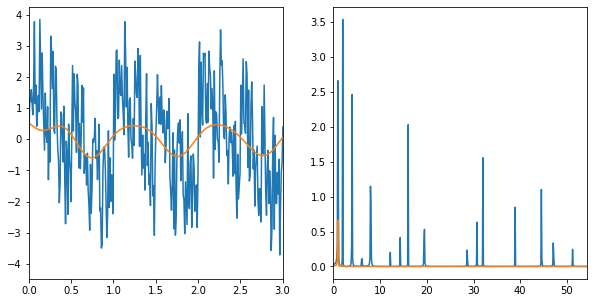

```python
N = 2**10
ts = np.linspace(0, 3*np.pi, N)
xs = np.zeros(N)
dt = np.diff(ts)[-1]
fs = np.linspace(0, 1/dt, N)

for i in range(0,16):
    xs += 0.9**i * np.sin(2 * np.pi * 2**i * ts)

ps = np.fft.fft(xs)
for i in range(N):
    if fs[i] > 2:
        ps[i] = 0.0

fft_xs = np.fft.ifft(ps)

plt.figure(figsize=(10,5))
plt.subplot(121)
plt.plot(ts, xs)
plt.plot(ts, fft_xs.real)
plt.xlim(0,3)

freqs, pows = periodogram(xs, 1/dt)
freqs2, pows2 = periodogram(fft_xs.real, 1/dt)
plt.subplot(122)
plt.plot(freqs, pows)
plt.plot(freqs2, pows2)
plt.xlim(0,freqs[-1])
```

## Links:

- [Dirac Comb](https://en.wikipedia.org/wiki/Dirac_comb)
- [Clear discussion](https://jakevdp.github.io/blog/2013/08/28/understanding-the-fft/) leading to a non-recursive vectorized version. Discusses implementing a cutoff below which we fall back on a DFT calculation, which will be faster for small sub problems.

```python
def integrate(func, ts):

    """integrate an array using Newton-Cotes trapezoid method. """

    import types
    if type(func) == types.FunctionType:
        data = func(ts)
    elif hasattr(func, '__len__') and (not isinstance(func, str)):
        data = func
    else:
        raise ValueError('Data provided is not a function or an array.')


    dt = (ts[-1] - ts[0]) / len(ts)
    return (sum(data[1:-1]) + (data[-1] + data[0])/2) * dt
```